# macrosyntR

Sami El Hilali

2022/11/09

An R package for evaluation of pair-wise synteny conservation at the genome-wide scale. It takes a table of orthologs and genome annotation files formatted as BED to automatically infer significantly conserved linkage groups, and order them on an oxford grid.

# Overview :

It has 5 functions :

| Function | description |
| --- | --- |
| load_orthologs() | integrates genomic coordinates (bedfiles) of the orthologs of the two species to compare |
| calculate_macrosynt() | compares all the chromosomes to each other and identifies the significantly conserved linkage groups |
| reorder_synteny() | takes an mbh_df (from load_mbh_df()) and outputs an mbh_df with chromosome levels reordered by cluster and amount of orthologs (run alone or by setting plot_oxford_grid(…,auto_order_clusters = TRUE) ) |
| plot_macrosynt() | draws a dotplot displaying the significant linkage groups with their relative amount of orthologs |
| plot_oxford_grid() | draws an oxford grid from an mbh_df (output of either load_mbh_df() or reorder_synteny() |

# Step-by-step tutorial :

We demonstrate the usage of the package using publicly available data.

- Branchiostoma floridae (Simakov et al. 2020)  
  data download : https://www.ncbi.nlm.nih.gov/genome/?term=txid7739)
- Paraescarpia echinospica (Sun et al. 2021)  
  (data download : https://doi.org/10.6084/m9.figshare.15050478.v1)

### 1 - Pre-process and Load the data :

#### Foreword :

This package doesn’t compute the orthologs. I recommend to compute it as mutual best hits using [rbhxpress](https://github.com/SamiLhll/rbhXpress). It is fast and accurate as it uses diamond blast.

Drawing the plots using this package require to have the following data :

- A two columns table of orthologs (mutual best hits). Each gene must appear only once in the table.
- genomic coordinates on species 1 for each gene having an ortholog.
- genomic coordinates on species 2 for each gene having an ortholog.

let’s say I have the following orthologs :

```bash
sp1.gene.x1  sp2.gene.y1
sp1.gene.X2  sp2.gene.y2
...
sp1.gene.xn  sp2.gene.yn
```

then, the genomic coordinates files must look like (BED format) :

- species1 :

```bash
chr4    200    600    sp1.gene.x1
chr8     10    400    sp1.gene.x2
...
chr12   900    980    sp1.gene.xn
```

- species2 :

```bash
chr1    100    200    sp2.gene.y1
chr6     50    200    sp2.gene.y2
...
chr8   300    480    sp2.gene.yn
```

#### Example :

I’m going to show how this package can help visualizing the linkage groups by comparing the data of the lancelet Branchiostoma floridae ([Simakov et al. 2020](https://doi.org/10.1038/s41559-020-1156-z)) with the data of the vestimentifera (giant tubeworm) Paraescarpia echinospica ([Sun et al. 2021](https://doi.org/10.1093/molbev/msab203)).

Download the sequences of proteins (fasta format) and their genomic coordinates :

- B.floridae : The data are available on ncbi at https://www.ncbi.nlm.nih.gov/genome/?term=txid7739  
  get the protein sequences at by clicking the “Download sequences in FASTA format for protein”.  
  get the genomic coordinates by clicking “Download genome annotation in tabular format” and further click download as csv.
- P.echinospica :  
  The data are available on figshare.  
  get the protein sequences here : https://figshare.com/ndownloader/files/28945467  
  get the genome annotation here : https://figshare.com/ndownloader/files/28945458

Compute the mutual best hits of the fasta sequences. Using rbhXpress you can achieve it by typing the following in your terminal :

```bash
 # In the terminal :
 # call mbhXpress with using 6 threads :
 bash mbhXpress -a GCF_000003815.2_Bfl_VNyyK_protein.faa -b Pec_ragoo_v1.0.pep.fasta -o Bflo_vs_Pech.tab -t 6
```

To convert the genome annotation to the [bed file format](https://www.ensembl.org/info/website/upload/bed.html), I’m using the following command lines (if unfamiliar with this you can use a spreadsheet software). The concept is to keep the chrom, chromStart, chromEnd mandatory fields plus the name optional field that links the genomic region with the protein product :

```bash
 # In the terminal :
 # B.floridae CSV file to bed
tail -n +2 proteins_75_971579.csv | cut -d "," -f1,3,4,9  | \
sed -e 's/\"//g' -e 's/,/\t/g' -e 's/chromosome /BFL/g' > Bflo.protein_products.bed

 # P.echinospica gff file to bed
fgrep "gene" Pec_genes.ragoo_v1.0.gff | cut -f1,4,5,9 | cut -d ";" -f 1 | \
fgrep "Superscaffold" | sed -e 's/ID=//g' -e 's/Superscaffold/PEC/g' > Pech.protein_products.bed

# Note that I further filtered the data attached with the package to save space by keeping only the coordinates of orthologous genes.
```

Now the data are ready to be loaded into R using macrosyntR :

```r
library(macrosyntR)
```

```r
my_orthologs_table <- load_orthologs(orthologs_table = "../inst/extdata/Bflo_vs_Pech.tab",
                                     sp1_bed = "../inst/extdata/Bflo.protein_products.bed",
                                     sp2_bed = "../inst/extdata/Pech.protein_products.bed")

head(my_orthologs_table)
```

```
#> # A tibble: 6 × 9
#>   sp1.ID    sp1.Chr sp1.Start sp1.End sp1.Index sp2.ID sp2.Chr sp2.End sp2.Index
#>   <chr>     <fct>       <int>   <int>     <int> <chr>  <fct>     <int>     <int>
#> 1 XP_03566… BFL19     9707570  9.71e6        67 PE_Sc… PEC3      36292         1
#> 2 XP_03569… BFL13     2651420  2.66e6        52 PE_Sc… PEC5      65489         1
#> 3 XP_03566… BFL19     6912491  6.93e6        42 PE_Sc… PEC12    107047         1
#> 4 XP_03566… BFL3     16747086  1.68e7       156 PE_Sc… PEC2     118807         1
#> 5 XP_03569… BFL13     7720510  7.74e6       130 PE_Sc… PEC5     133990         2
#> 6 XP_03566… BFL3     16741674  1.67e7       155 PE_Sc… PEC2     140279         2
```

### 2 - Compute linkage groups and plot :

Let’s compute the pairs of chromosomes that have a significant amount of orthologs using calculate_macrosynt(). We can visualize the results on a dot plot using plot_macrosnyt() and see the distributions of orthologs on an oxford grid using plot_oxford_grid()

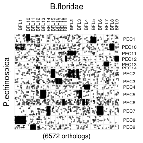

```r
# visualize the loaded data on a oxford grid :
plot_oxford_grid(my_orthologs_table,
                 sp1_label = "B.floridae",
                 sp2_label = "P.echinospica")
```

```r
# compute significance and visualize on a dotplot :
macrosynteny_df <- calculate_macrosynt(my_orthologs_table)
head(macrosynteny_df)
```

```
#>   sp1.Chr sp2.Chr orthologs         pval significant  pvalues_adj
#> 1    BFL1    PEC1        18 1.000000e+00          no 1.000000e+00
#> 2    BFL1   PEC10        90 2.711003e-07         yes 6.425078e-05
#> 3    BFL1   PEC11         5 1.000000e+00          no 1.000000e+00
#> 4    BFL1   PEC12        13 1.000000e+00          no 1.000000e+00
#> 5    BFL1   PEC13        11 1.000000e+00          no 1.000000e+00
#> 6    BFL1   PEC14         2 9.999988e-01          no 1.000000e+00
```

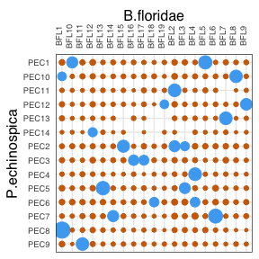

```r
plot_macrosynt(macrosynteny_df,
               sp1_label = "B.floridae",
               sp2_label = "P.echinospica")
```

### 3 - Reorder chromosome levels to group the linkage groups in clusters :

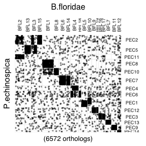

```r
# visualize the loaded data on a oxford grid :
my_orthologs_table_reordered <- reorder_synteny(my_orthologs_table)
plot_oxford_grid(my_orthologs_table_reordered,
                 sp1_label = "B.floridae",
                 sp2_label = "P.echinospica")
```

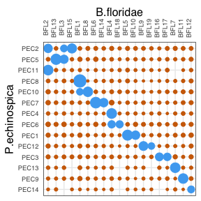

```r
# compute significance and visualize on a dotplot :
macrosynteny_df_reordered <- calculate_macrosynt(my_orthologs_table_reordered)
plot_macrosynt(macrosynteny_df_reordered,
               sp1_label = "B.floridae",
               sp2_label = "P.echinospica")
```

### 4 - Plot directly with reordering the linkage groups and coloring the clusters :

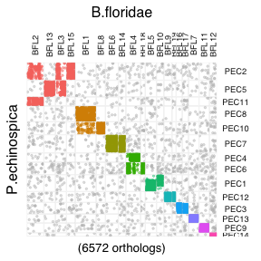

```r
# visualize the loaded data on a oxford grid :
plot_oxford_grid(my_orthologs_table,
                 sp1_label = "B.floridae",
                 sp2_label = "P.echinospica",
                 auto_order_clusters = TRUE,
                 color_clusters = TRUE)
```

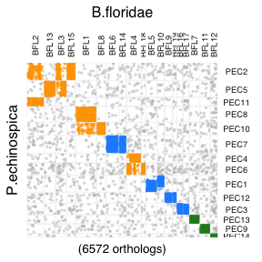

```r
# Change the vector of colors, 1 color per cluster, we see on the plot above that we have 10 clusters :
plot_oxford_grid(my_orthologs_table,
                 sp1_label = "B.floridae",
                 sp2_label = "P.echinospica",
                 auto_order_clusters = TRUE,
                 color_clusters = TRUE,
                 clusters_color_palette = c("#FFA500","#FFA500", "#1E90FF","#FFA500", "#1E90FF", "#1E90FF", "#1E90FF", "#228B22", "#228B22", "#228B22"))
```